# TCPSR種子計畫Lecture02 HW09 example

陳紹慶

2022-05-23

## 示範資料說明

```r
## import the raw data and convert into long table
all_data <- bind_rows(
  readxl::read_xlsx("curve fitting data.xlsx",sheet = "Normal_FACE") %>%
  pivot_longer(NT001:NT024,names_to = "ID",values_to = "Response") %>% bind_cols(Group = "NT",Condition = "Face"),

readxl::read_xlsx("curve fitting data.xlsx",sheet = "Autism_FACE") %>%
  pivot_longer(AS001:AS024,names_to = "ID",values_to = "Response") %>% bind_cols(Group = "ASD",Condition = "Face"),

readxl::read_xlsx("curve fitting data.xlsx",sheet = "Normal_OBJ") %>%
  pivot_longer(NT001:NT024,names_to = "ID",values_to = "Response") %>% bind_cols(Group = "NT",Condition = "Object"),

readxl::read_xlsx("curve fitting data.xlsx",sheet = "Autism_OBJ") %>%
  pivot_longer(AS001:AS024,names_to = "ID",values_to = "Response") %>% bind_cols(Group = "ASD",Condition = "Object"))
```

熊恩筠 et al. (2022) 邀請24位ASD組群人士及24位一般成 人，進行變形臉孔區辨作業與變形物體區辨作業，比較兩組參與者辨識臉孔與物體正確率達75%的最低變形程度閾值。變形臉孔區辨作業操作臉孔變形程度(15%,30%,45%,60%,75%)，變形物體區辨作業操作臉孔變形程度(12%,24%,36%,48%,60%)，研究者紀錄參與者能正確辨識目標臉孔的次數。研究結果顯示只有變形臉孔區辨作業的部分條件 出現組間差異，若要重製或延伸這項研究，我們能如何評估效果量及事後考驗力？

感謝簡惠玲老師提供去識別化的可處理研究資料。歡迎使用本文源始Rmd及參考文獻bib重製及編輯分析結果。

## 重製原始論文圖4

原始資料格式是寬表單，轉換為長表單以利重製。首先計算個別參與者在不同變形程度的正確率(Acc)，再依作業情境(Condition: Face, Object)、參與者組別(Group: ASD, NT)以及變形程度(參考前一節)總計各組正確次數總和(SUM), 平均正確率(Mean)、正確率估計標準誤。

```r
## summary data
plot_data <- all_data %>% mutate(Acc = if_else(Condition == "Face",Response/8,Response/12)) %>%
  group_by(Condition, Group, morph_level) %>%
  summarise(SUM = sum(Response),round(mean_se(Acc),3)) %>%
  rename(Mean = y) %>%
  mutate(Condition=as.factor(Condition),
         Group = as.factor(Group))
```

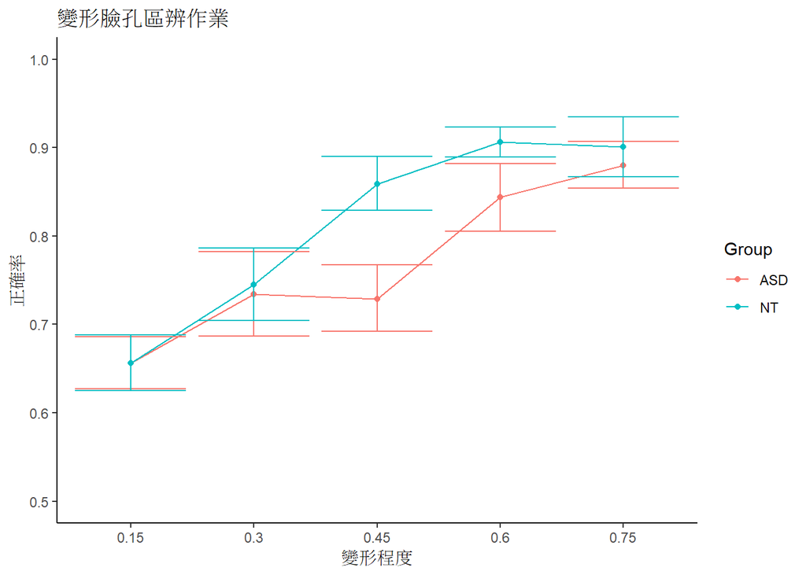

```r
## Draw line plot for face condition
plot_data %>% filter(Condition == "Face") %>%
  mutate(morph_level = as.factor(morph_level)) %>%
  ggplot(aes(x=morph_level,y=Mean,group=Group,color=Group)) +
    geom_point() +
    geom_line()+
    geom_errorbar(aes(ymax=ymax,ymin=ymin))+
    coord_cartesian(ylim=c(0.5,1))+
    labs(title="變形臉孔區辨作業")+
    xlab("變形程度")+
    ylab("正確率")+
    theme_classic()
```

變形臉孔區辨作業正確率趨勢圖與論文圖4左一致，可見變形程度0.45有組間差異。

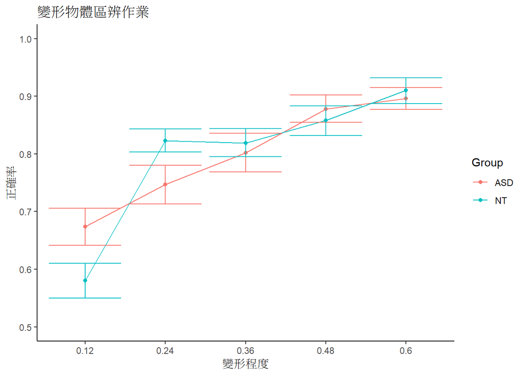

```r
## Draw line plot for face condition
plot_data %>% filter(Condition == "Object")  %>%
  mutate(morph_level = as.factor(morph_level)) %>%
  ggplot(aes(x=morph_level,y=Mean,group=Group,color=Group)) +
    geom_point() +
    geom_line()+
    geom_errorbar(aes(ymax=ymax,ymin=ymin))+
    coord_cartesian(ylim=c(0.5,1))+
    labs(title="變形物體區辨作業")+
    xlab("變形程度")+
    ylab("正確率")+
    theme_classic()
```

變形物體區辨作業正確率趨勢圖與論文圖4右一致，兩組趨勢無明顯差異。

## 重製原始論文圖5及報告

熊恩筠 et al. (2022) 運用[Daniel Linares](https://www.dlinares.org/)開發的R套件[quickpsy](http://dlinares.org/quickpsy.html)，估計兩組參與者的區辨閾值及比較組間差異。概覽範例，主要用於估計及比較同一位參與者在兩種條件分別測得閾值。由於bootstraping為隨機亂數抽樣，但是**[quickpsy](http://dlinares.org/quickpsy.html)沒有設定隨機種子的機制，若不事先設定，每次重製的結果都有些微差異**。無法確定兩組閾值的差異有統計的顯著意義。

此外 熊恩筠 et al. (2022) 的報告對於信賴區間的解釋並不完整，寫作建議符合APA格式如以下示範：

以下節錄原文：

> “一般成 人組區辨閾值約落在變形程度 25.87% 之處，ASD 組 的區辨閾值則落在 33.12% 的變形程度處… 估計標準誤並計算區辨 閾值的 95% 信賴區間（confidence interval, CI） … ，ASD 組的閾值落在 一般成人組閾值的 95% CI 之外，故兩組差異達顯著。… 一般成人組區辨閾值落 在變形程度 23.12% 之處；ASD 組的區辨閾值落在變形 程度 21.67% 之處，仍在一般成人組閾值的 95% CI 內， 差異未達顯著。”

**重製與更正**：

- 比較ASD與一般成人的臉孔區辨閾值

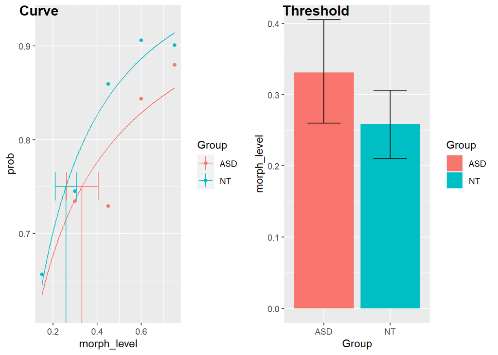

```r
dt <- subset(plot_data, Condition == "Face" ) %>% bind_cols(N = 192) %>% mutate(Group=as.character(Group) )

set.seed(529) ## test seed number
fitFace <- quickpsy(dt, morph_level, SUM, N, prob=.75, grouping =.(Group), fun = weibull_fun) ## some outputs are embedded in text, see the source Rmd.

cowplot::plot_grid(plot(fitFace), plotthresholds(fitFace), labels = c('Curve', 'Threshold'))
```

一般成人組區辨閾值為25.87% 95% CI [21.06, 30.59]；ASD組的區辨閾值為33.12% 95% CI[26.01, 40.52]。兩組區辨閾值差異估計值為7.25% 95% CI[-0.11, 17]。

**註** 若無設定隨機種子，每次重製區辨閾值差異估計值會有變化，應在事前設定隨機種子。

- 比較ASD與一般成人的物體區辨閾值

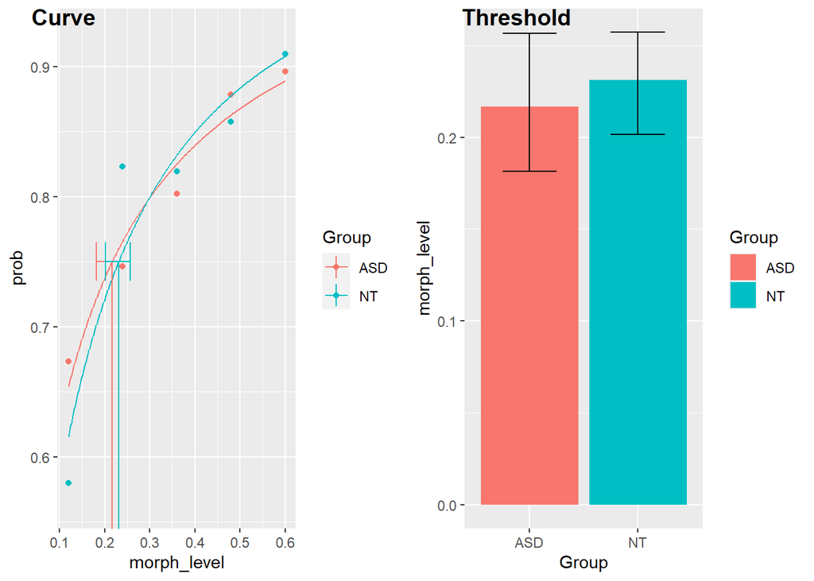

```r
dt <- subset(plot_data, Condition == "Object" ) %>% bind_cols(N = 288) %>% mutate(Condition=as.character(Condition),Group=as.character(Group))

set.seed(529)  ## test seed number
fitObj <- quickpsy(dt, morph_level, SUM, N, prob=.75, grouping =.(Group), fun = weibull_fun) ## some outputs are embedded in text, see the source Rmd.


cowplot::plot_grid(plot(fitObj), plotthresholds(fitObj), labels = c('Curve', 'Threshold'))
```

## 分組差異效果量及重製研究預估樣本

### 以正確率差異進行考驗力分析

```r
Face_045 <- all_data %>% filter(Condition=="Face", morph_level == 0.45) %>%
  mutate(Group = as.factor(Group))

results_d <- cohens_d(Response~Group,data=Face_045,alternative = "less") %>% unlist  ## -0.78 95%CI [-Inf, -0.28]
```

原始結果的事後考驗力

```r
pwr::pwr.t.test(n = 24,d = results_d[1],type = "two.sample",alternative = "less")
```

```
##
##      Two-sample t test power calculation
##
##               n = 24
##               d = -0.780389
##       sig.level = 0.05
##           power = 0.8457528
##     alternative = less
##
## NOTE: n is number in *each* group
```

相同設計要達到90%考驗力，各組所需人數預估：

```r
pwr::pwr.t.test(d = results_d[1],power = .9,type = "two.sample",alternative = "less")
```

```
##
##      Two-sample t test power calculation
##
##               n = 28.82645
##               d = -0.780389
##       sig.level = 0.05
##           power = 0.9
##     alternative = less
##
## NOTE: n is number in *each* group
```

**註** 區辨閾值非原始測量變項，建議考慮作業項目數做為樣本單位，才能獲得符合設計的效果量估計值。

### 參考文獻

熊恩筠, 簡惠玲, 高千惠, and 彭馨蕾. 2022. “比較自閉症成人與一般成人的臉孔和物體區辨能力：以變形典範探討.” *中華心理學刊* 64 (1): 33–55. https://doi.org/10.6129/CJP.202203_64(1).0002.